# Part I - (Prosper Load Data)

### Loan Status

```python
df["LoanStatus"].value_counts()
```

```
Current                   55730
Completed                 38061
Chargedoff                11992
Defaulted                  5017
Past Due (1-15 days)        800
Past Due (31-60 days)       361
Past Due (61-90 days)       311
Past Due (91-120 days)      304
Past Due (16-30 days)       265
FinalPaymentInProgress      203
Past Due (>120 days)         16
Cancelled                     4
Name: LoanStatus, dtype: int64
```

```python
# Instead of these statuses we can make it "Active" or "Inactive" using the "ClosedDate" variable
df.loc[df['ClosedDate'].isnull(), 'IsActive'] = 1
df.loc[df['ClosedDate'].notnull(), 'IsActive'] = 0
df["IsActive"].value_counts()
```

```
1.0    57990
0.0    55074
Name: IsActive, dtype: int64
```

```python
# better to make it boolean
df["IsActive"] = df['IsActive'].astype('bool')
```

```
Text(0.5,1,'Active loans')
```

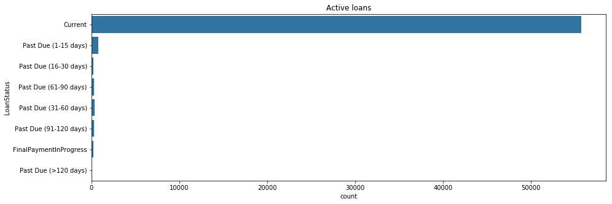

```python
# Let's look at the active loans
activeLoans = df[df["IsActive"] == 1]
plt.figure(figsize=(15,5))

# set color
color = sns.color_palette()[0]

sns.countplot(data = activeLoans , y = 'LoanStatus', color = color, orient = 'h')
plt.title('Active loans')
```

```
Text(0.5,1,'Active loans (Without Current Status)')
```

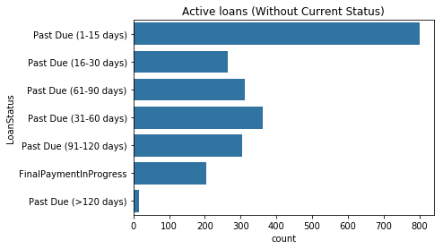

```python
# Most of active loans are in current status, with no issues
# What if we wanted to see other values, we can exclude the "current" status from the plot
activeLoansWithoutCurrent = activeLoans[activeLoans["LoanStatus"] != "Current"]
sns.countplot(data = activeLoans[activeLoans["LoanStatus"] != "Current"], y = 'LoanStatus', color = color, orient = 'h')
plt.title('Active loans (Without Current Status)')
```

```
Text(0.5,1,'Active loans (Without Current Status)')
```

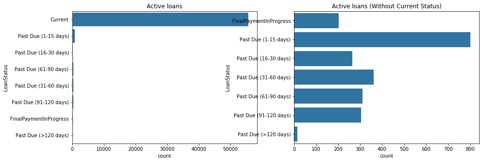

```python
# let's give it some logical order and plot both plots together
activeLoans = df[df["IsActive"] == 1]

plt.figure(figsize=(15,5))
plt.subplot(1,2,1)

# set color
color = sns.color_palette()[0]

sns.countplot(data = activeLoans , y = 'LoanStatus', color = color, orient = 'h')
plt.title('Active loans')

plt.subplot(1,2,2)
order = order = ['FinalPaymentInProgress', 'Past Due (1-15 days)', 'Past Due (16-30 days)',
         'Past Due (31-60 days)', 'Past Due (61-90 days)', 'Past Due (91-120 days)', 'Past Due (>120 days)']
activeLoansWithoutCurrent = activeLoans[activeLoans["LoanStatus"] != "Current"]
sns.countplot(data = activeLoans[activeLoans["LoanStatus"] != "Current"], y = 'LoanStatus', order = order, color = color, orient = 'h')
plt.title('Active loans (Without Current Status)')
```

```python
# let's do the same with inactive loans
```

```
Text(0.5,1,'inActive loans (Without Current Status)')
```

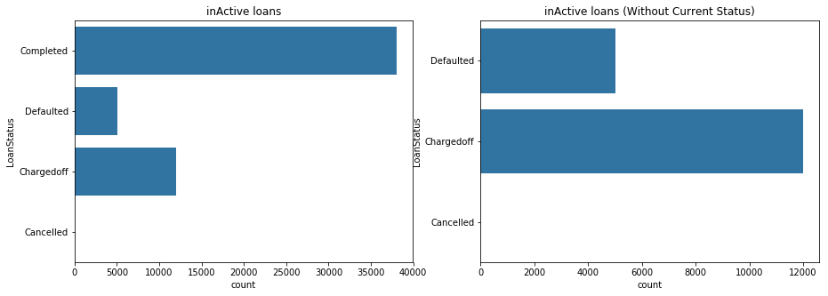

```python
inactiveLoans = df[df["IsActive"] == 0]

plt.figure(figsize=(15,5))
plt.subplot(1,2,1)

# set color
color = sns.color_palette()[0]

sns.countplot(data = inactiveLoans , y = 'LoanStatus', color = color, orient = 'h')
plt.title('inActive loans')

plt.subplot(1,2,2)
order = order = ['Defaulted', 'Chargedoff', 'Cancelled']
inactiveLoansWithoutCurrent = inactiveLoans[inactiveLoans["LoanStatus"] != "Completed"]
sns.countplot(data = inactiveLoansWithoutCurrent, y = 'LoanStatus', order = order, color = color, orient = 'h')
plt.title('inActive loans (Without Current Status)')
```

- Most of closed loans are "Completed" (Paid)

### LoanOriginalAmount

```python
df["LoanOriginalAmount"].describe()
```

```
count    113064.000000
mean       8314.878432
std        6237.001092
min        1000.000000
25%        4000.000000
50%        6300.000000
75%       12000.000000
max       35000.000000
Name: LoanOriginalAmount, dtype: float64
```

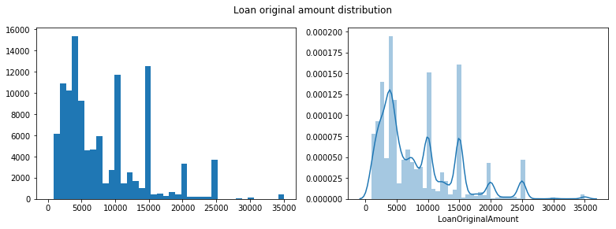

```python
plt.figure(figsize=(13,4))
plt.suptitle('Loan original amount distribution')
plt.subplot(1,2,1)
bins = np.arange(0, df['LoanOriginalAmount'].max()+900, 900)
plt.hist(data = df, x = 'LoanOriginalAmount', bins = bins)

plt.subplot(1,2,2)
sns.distplot(df['LoanOriginalAmount']);
```

- Loan amounts are right skewed with several peaks.
- The most frequently amount is 4000.

### CreditGrade and ProsperRating¶

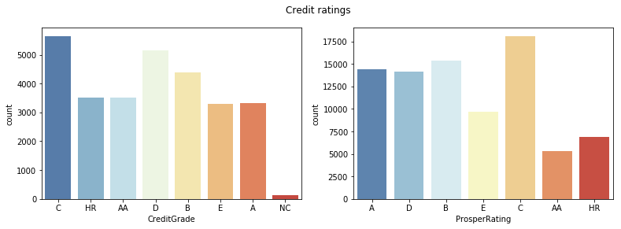

```python
plt.figure(figsize=(13,4))
plt.suptitle("Credit ratings")
plt.subplot(1,2,1)
sns.countplot(data = df, x = 'CreditGrade', palette = 'RdYlBu_r')
plt.subplot(1,2,2)
sns.countplot(data = df, x = 'ProsperRating', palette = 'RdYlBu_r');
```

```
Text(0.5,1,'ProsperRating')
```

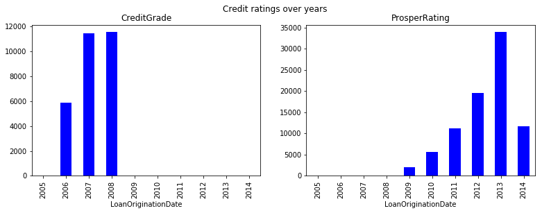

```python
plt.figure(figsize=(13,4))
plt.suptitle("Credit ratings over years")
plt.subplot(1,2,1)
df.groupby(df["LoanOriginationDate"].dt.year).count()['CreditGrade'].plot(kind='bar', color = 'b')
plt.title('CreditGrade')


plt.subplot(1,2,2)
df.groupby(df["LoanOriginationDate"].dt.year).count()['ProsperRating'].plot(kind='bar', color = 'b')
plt.title('ProsperRating')
```

- Seems like the "CreditGrade" was used until 2009 when the "ProperRating" comes to play

```python
# we can create a new variable to represent the credit rating
# "CreditRating" = "CreditGrade" before 2009 and = "ProsperRating" after then
df["CreditRating"] = np.where(df["CreditGrade"].isnull(), df["ProsperRating"], df["CreditGrade"])
```

```python
# convert it into ordinal categorical variable
var_dict = ['AA', 'A', 'B', 'C', 'D', 'E', 'HR', 'NC']
df["CreditRating"] = df['CreditRating'].astype(pd.api.types.CategoricalDtype(ordered=True, categories = var_dict))
```

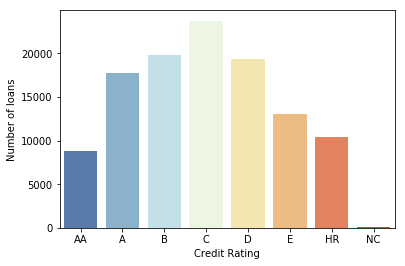

```python
sns.countplot(data = df, x = 'CreditRating', palette = 'RdYlBu_r')
plt.xlabel('Credit Rating')
plt.ylabel('Number of loans');
```

### IncomeVerifiable¶

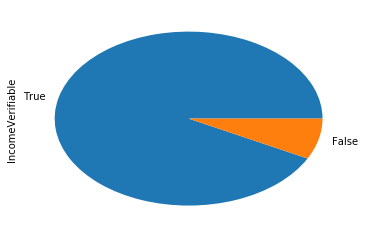

```python
df["IncomeVerifiable"].value_counts().plot(kind='pie');
```

- Most of borrowers have a verifiable income.

### StatedMonthlyIncome

```python
df["StatedMonthlyIncome"].describe()
```

```
count    1.130640e+05
mean     5.605142e+03
std      7.495656e+03
min      0.000000e+00
25%      3.199521e+03
50%      4.666667e+03
75%      6.825000e+03
max      1.750003e+06
Name: StatedMonthlyIncome, dtype: float64
```

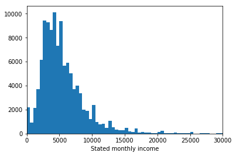

```python
bins = np.arange(0, 30500, 500)
plt.hist(data = df, x = 'StatedMonthlyIncome', bins = bins)
plt.xlabel('Stated monthly income')
plt.xlim((0,30000));
```

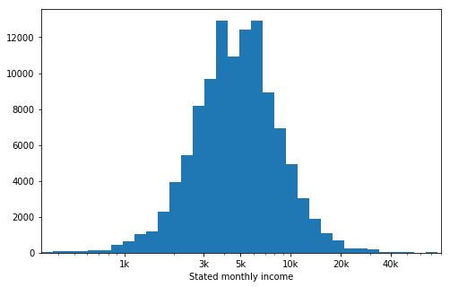

```python
# monthly income is right skewed
# let's try to transform it to logs

log_binsize = 0.07
bins = 10 ** np.arange(2.5, np.log10(df['StatedMonthlyIncome'].max())+log_binsize, log_binsize)

plt.figure(figsize=[8, 5])
plt.hist(data = df, x = 'StatedMonthlyIncome', bins = bins)
plt.xscale('log')
plt.xticks([1000, 3000, 5000, 10000, 20000, 40000], ['1k', '3k', '5k', '10k', '20k', '40k'])
plt.xlim((0,80000))
plt.xlabel('Stated monthly income')
plt.show()
```

The distribution looks normal after the transformation.

### EmploymentStatus

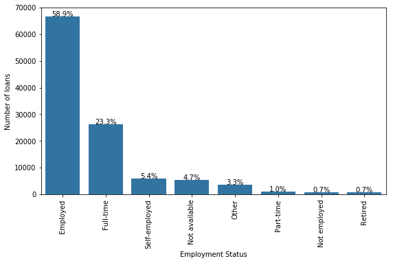

```python
plt.figure(figsize=[9, 5])
status_counts = df['EmploymentStatus'].value_counts()
status_order = status_counts.index
max_count = status_counts[0]
max_prop = max_count / df.shape[0]
tick_props = np.arange(0, max_prop, 0.1)
tick_names = ['{:0.2f}'.format(v) for v in tick_props]

g = sns.countplot(data = df, x = 'EmploymentStatus', color = color, order = status_order)
plt.xticks(rotation = 90)
plt.xlabel('Employment Status')
plt.ylabel('Number of loans')


# values must be ordered from the largest for this to work
for i in range(status_counts.shape[0]):
    count = status_counts[i]
    pct_string = '{:0.1f}%'.format(100 * count / df.shape[0])
    plt.text(i, count+10, pct_string, ha = 'center')
```

- Most of borrowers are employed.

### Interest Rate

```python
df["BorrowerAPR"].describe()
```

```
count    113039.000000
mean          0.218982
std           0.080483
min           0.006530
25%           0.156290
50%           0.209840
75%           0.283860
max           0.512290
Name: BorrowerAPR, dtype: float64
```

```
Text(0.5,0,'Loan origination year')
```

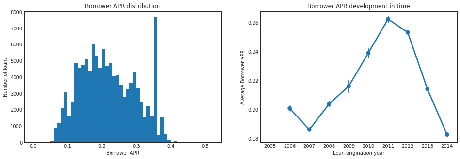

```python
sns.set_style("white")
plt.figure(figsize=(16,5))

plt.subplot(1,2,1)
bins = np.arange(0, df["BorrowerAPR"].max()+0.01, 0.01)
plt.hist(data = df.dropna(subset=["BorrowerAPR"]), x = 'BorrowerAPR', bins = bins)
plt.title('Borrower APR distribution')
plt.xlabel('Borrower APR')
plt.ylabel('Number of loans')


plt.subplot(1,2,2)
sns.pointplot(data = df, x = df['LoanOriginationDate'].dt.year, y = 'BorrowerAPR')
plt.title('Borrower APR development in time')
plt.ylabel('Average Borrower APR')
plt.xlabel('Loan origination year')
```

- The most frequent rates are also in the high end of 0.35 - 0.37.
- The average interest rate was increasing steeply between 2007-2011, but it is decreasing since then.

## Bivariate Exploration

### Numeric variables

```python
# since we have a lot of data points, let's take a sample of 5000
sample = np.random.choice(df.shape[0], 5000, replace = False)
df_samp = df.iloc[sample,:]
```

LoanOriginalAmount VS MonthlyLoanPayment

```
(0, 1500)
```

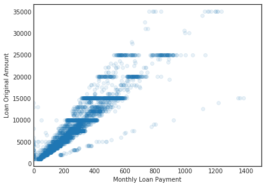

```python
plt.figure(figsize = (15,5))
plt.subplot(1,2,1)
plt.scatter(data = df_samp, x = 'MonthlyLoanPayment', y = 'LoanOriginalAmount', alpha = 1/10)
plt.ylabel('Loan Original Amount')
plt.xlabel('Monthly Loan Payment')
plt.xlim((0,1500))
```

```python
coef = df[['MonthlyLoanPayment', 'LoanOriginalAmount']].corr().iloc[1,0]
coef
```

```
0.93185508719514254
```

- Make sense, strong positive relatioshio

### Categorical Variables

```python
# sample of 2000
samples = np.random.choice(df.shape[0], 1000, replace = False)
df_samp = df.iloc[samples,:]

def boxgrid(x, y, **kwargs):
    """ Function for creating box plots with seaborn's PairGrid. """
    default_color = sns.color_palette()[0]
    sns.boxplot(x, y, color = default_color)
```

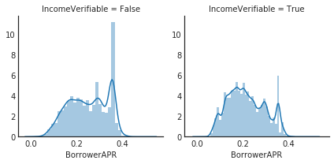

```python
g = sns.FacetGrid(data = df, col = 'IncomeVerifiable')
g.map(sns.distplot, 'BorrowerAPR');
```

- Borrowers with a verifiable income benefit from lower rate.

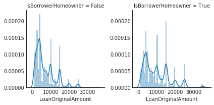

```python
g = sns.FacetGrid(data = df, col = 'IsBorrowerHomeowner')
g.map(sns.distplot, 'LoanOriginalAmount');
```

- Borrowers who own home get higher loan amounts.

## Multivariate Exploration

> Create plots of three or more variables to investigate your data even further. Make sure that your investigations are justified, and follow from your work in the previous sections.

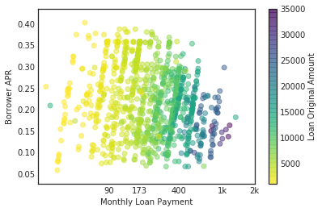

```python
plt.scatter(data = df_samp, x = 'MonthlyLoanPayment', y = 'BorrowerAPR', alpha = 1/2, c = 'LoanOriginalAmount', \
            cmap = 'viridis_r')
plt.colorbar(label = 'Loan Original Amount')
plt.ylabel('Borrower APR')
plt.xlabel('Monthly Loan Payment')
plt.xlim((20,2000))
plt.xscale('log')
plt.xticks([90, 173, 400, 1e3, 2e3], [90, 173, 400, '1k', '2k'])
plt.show()
```

- higher loan amounts have lower interest rate and higher monthly payments

```python
df.to_csv("data.csv")
```

```python
from subprocess import call
call(['python', '-m', 'nbconvert', 'Part_I_exploration_template.ipynb'])
```